# Categorical Variables

Yuanting Lu

07/22/2020

## Notes

### Load Data

The first dataset that we are going to look at is named Credit, a simulated data set containing information of a large number of customers. It is in the library ISLR[^1]. Therefore, we will install this library in order to access the dataset. Type `install.packages("ISLR")` in the R console.

```r
library(ISLR) # Loading the package ISLR.
```

### Data Set Summary

1. How large is this data set?

```r
dim(Credit) # The dimension (rows by columns) of the data set
```

2. What are the columns?

```r
names(Credit)
```

3. Which of the variables are categorical? Which ones are numerical? We can take a peek of the data set by viewing its first a few rows (e.g., first 10 rows).

```r
head(Credit, 10) # The head function shows the first a few rows of the data set.
```

A detailed explanation of the data set can be found by `?Credit` or `help(Credit)` in the console.

### Graphs

1. Create a frequency table for a variable.

```r
table(Credit$Student) # summary(Credit) also works
```

To convert the frequency table to a relative frequency table, we can divide the numbers in the table by the total number of customers in the data set. If you remember the total number of customers is 400, do `table(Credit$Student) / 400`. Otherwise, we can use the **length** function to calculate the total so that we do `table(Credit$Student) / length(Credit$Student)`.

2. Create a pie chart.

```r
freq <- table(Credit$Student)
pie(freq, main = "Student Status")
```

```r
barplot(freq, main = "Student Status")
```

- How to make the y-axis display relative frequency?
- How to change the labels from Yes/No to Student/Non-student?

Other ways to display categorical data.

4. Donut plot. This donut function is not a built-in R function. It is included in the nicer.R file written by your instructor.

```r
source("https://albums.yuanting.lu/sta126/nicer.R")
donut(freq, main = "Student Status")
```

### [Bonus] Graphic Skills +

Below you will learn how to customize graphs.

- Customized colors.
  - The **col = c(“lightblue”, “lightcoral”)** option provides two colors to the graph.
  - The **c** function combines its arguments (e.g., “lightblue”, “lightcoral”) and creates a vector.
- Customized group tags.
  - The **labels** option allows us to change the group tags in a pie chart.
  - The **names** option allows us to change the group tags in a bar graph.
- Customize text labels on the y-axis.
  - The **ylab** option allows us to change the text label on the y-axis.
- Use lines to shade bars and slices.
  - The **density** option provides the density of line segments to each bar or slice.
  - The **angle** option sets the angles of the line segments (in degrees).

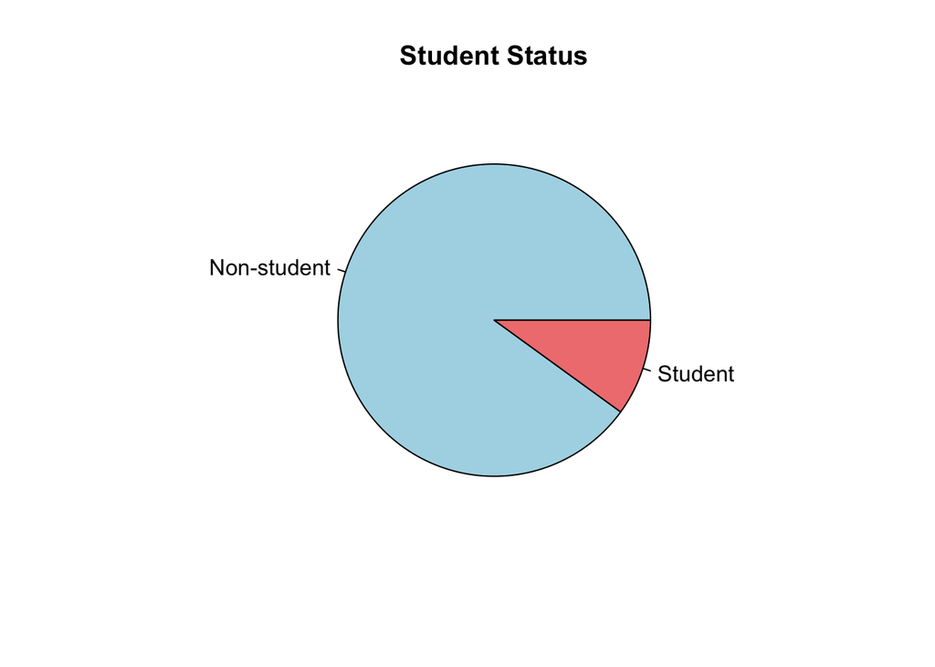

```r
library(ISLR)
freq <- table(Credit$Student)
pie(freq,
    col = c("lightblue", "lightcoral"),
    labels = c("Non-student", "Student"),
    main = "Student Status")
```

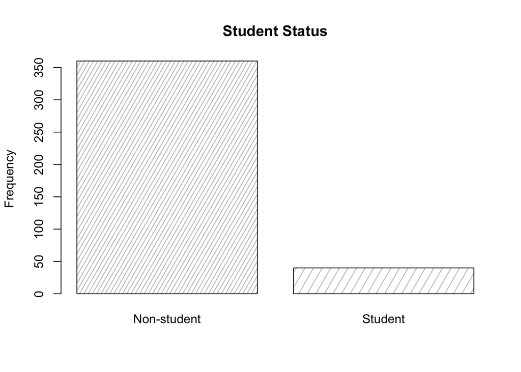

```r
barplot(freq,
        density = c(20, 10),
        angle = 60,
        names = c("Non-student", "Student"),
        ylab = "Frequency",
        main = "Student Status")
```

## Online R Editor

This is for quick demonstration only. Your work in here can **NOT** be saved.

[interactive chart not shown]

## Whiteboard

[interactive chart not shown]

[⇦ Back to the course homepage.](https://albums.yuanting.lu/sta126/)

[^1]: Gareth James, Daniela Witten, Trevor Hastie, Robert Tibshirani. (2013). *An introduction to statistical learning : with applications in R*. New York: Springer.